# HW #5 - Multilevel Models

Author

David Gonzalez Chavez

# Preliminaries

```r
d <- read_rds("ess5000.rds")
```

## 1. Describe the data

```r
psych::describe(d)
```

```
                      vars    n   mean    sd median trimmed   mad   min    max
cntry*                   1 5000  15.79  7.45  13.00   15.77  8.90  1.00  29.00
country                  2 5000  15.79  7.45  13.00   15.77  8.90  1.00  29.00
ppltrst                  3 5000   4.87  2.36   5.00    4.96  2.97  0.00  10.00
vote                     4 5000   0.77  0.42   1.00    0.84  0.00  0.00   1.00
stflife                  5 5000   6.74  2.34   7.00    6.94  1.48  0.00  10.00
euftf                    6 5000   5.16  2.74   5.00    5.20  2.97  0.00  10.00
agea                     7 5000  48.41 17.32  48.00   48.04 20.76 15.00 101.00
eduyrs                   8 5000  12.98  3.66  13.00   13.05  2.97  0.00  20.00
incdecile                9 4094   5.52  2.77   6.00    5.50  2.97  1.00  10.00
region                  10 5000 194.93 92.94 202.50  195.17 97.11  1.00 350.00
female                  11 5000   0.54  0.50   1.00    0.55  0.00  0.00   1.00
attend                  12 5000   2.54  1.52   2.00    2.38  1.48  1.00   7.00
health                  13 5000   3.67  0.90   4.00    3.72  1.48  1.00   5.00
gnipc1000               14 5000  29.96 17.10  32.83   29.42 14.14  2.99 102.07
c_imf_cond_any          15 5000   0.19  0.39   0.00    0.12  0.00  0.00   1.00
c_fhpr_2012             16 5000   2.10  1.87   1.00    1.75  0.00  1.00   6.00
c_fhstanu_2012          17 5000   1.61  0.75   2.00    1.76  0.00  0.00   2.00
c_assn_2011             18 5000   1.41  0.76   2.00    1.52  0.00  0.00   2.00
c_disap_2011            19 5000   1.53  0.85   2.00    1.66  0.00  0.00   2.00
c_dommov_2011           20 5000   1.98  0.18   2.00    2.00  0.00  0.00   2.00
c_elecsd_2011           21 5000   1.58  0.75   2.00    1.72  0.00  0.00   2.00
c_empinx_2011           22 5000   9.80  3.59  11.00   10.38  1.48  2.00  13.00
c_formov_2011           23 5000   1.56  0.76   2.00    1.70  0.00  0.00   2.00
c_injud_2011            24 5000   1.42  0.86   2.00    1.52  0.00  0.00   2.00
c_kill_2011             25 5000   1.41  0.76   2.00    1.51  0.00  0.00   2.00
c_polpris_2011          26 5000   1.38  0.76   2.00    1.48  0.00  0.00   2.00
c_relfre_2011           27 5000   1.31  0.86   2.00    1.39  0.00  0.00   2.00
c_speech_2011           28 5000   0.95  0.52   1.00    0.94  0.00  0.00   2.00
c_tort_2011             29 5000   1.08  0.77   1.00    1.10  1.48  0.00   2.00
c_wecon_2011            30 5000   2.14  0.80   2.00    2.17  1.48  1.00   3.00
c_wopol_2011            31 5000   2.32  0.47   2.00    2.27  0.00  2.00   3.00
c_worker_2011           32 5000   1.01  0.57   1.00    1.01  0.00  0.00   2.00
c_accountability_2012   33 5000   0.75  0.87   1.06    0.86  0.48 -0.96   1.75
c_corruption_2012       34 5000   0.72  1.13   1.05    0.75  1.09 -1.03   2.39
c_effectiveness_2012    35 5000   0.85  0.83   1.11    0.89  0.69 -0.58   2.21
c_law_2012              36 5000   0.78  0.98   1.04    0.85  0.96 -0.82   1.95
c_quality_2012          37 5000   0.86  0.77   0.97    0.92  0.84 -0.61   1.89
c_stability_2012        38 5000   0.36  0.65   0.50    0.41  0.63 -1.15   1.40
c_ticpi_2013            39 5000  58.35 20.74  60.00   58.98 25.20 25.00  91.00
```

[output cut: 31 more lines]

```
c_speech_2011           2.00  -0.07     0.70 0.01
c_tort_2011             2.00  -0.13    -1.29 0.01
c_wecon_2011            2.00  -0.25    -1.38 0.01
c_wopol_2011            1.00   0.77    -1.40 0.01
c_worker_2011           2.00   0.00     0.09 0.01
c_accountability_2012   2.72  -1.12    -0.26 0.01
c_corruption_2012       3.42  -0.43    -1.26 0.02
c_effectiveness_2012    2.80  -0.54    -1.12 0.01
c_law_2012              2.77  -0.66    -1.08 0.01
c_quality_2012          2.50  -0.74    -0.78 0.01
c_stability_2012        2.55  -0.71    -0.53 0.01
c_ticpi_2013           66.00  -0.38    -1.27 0.29
dweight                 3.88   2.35     9.66 0.01
pweight                 5.41   0.46    -0.81 0.02
wt                     19.52   1.85     5.73 0.03
```

The mean of ppltrst is 4.8678 and the variance of ppltrst is 5.5470326.

## 2. Histogram of ppltrst

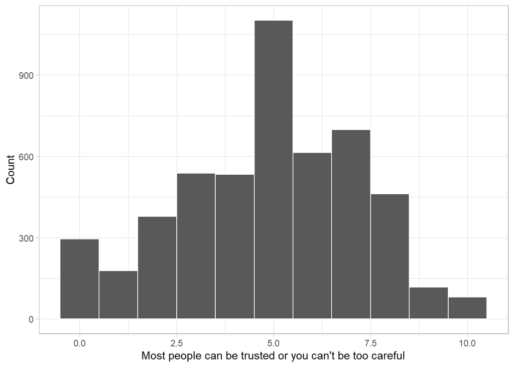

```r
ggplot(aes(x = ppltrst),
       data = d) +
  geom_histogram(color = "white",
                 binwidth = 1) +
  ylab("Count")
```

The modal value is 5, as the plurality of respondents answers 5.0 to the question.

## 3. Distribution of ppltrust By Country

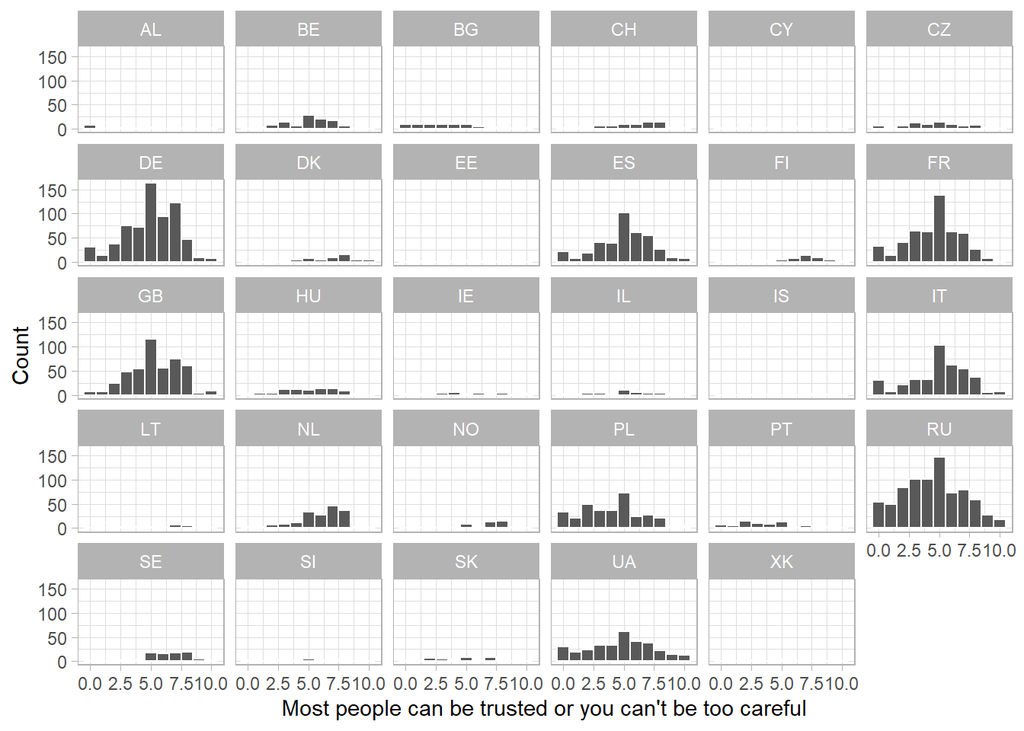

```r
ggplot(aes(x = ppltrst),
       data = d) +
  geom_histogram(color = "white",
                 binwidth = 1) +
  ylab("Count") +
  facet_wrap(~ cntry)
```

For most countries there are very few datapoints. As a result, partial pooling will probably result in predicted country means for those countries with little information to shift to be closer to the overall pooled mean.

# Single Dimension

## 4. Variance Components Model

```r
m1 <- lmer(ppltrst ~ 1 + (1 | cntry),
           data = d,
           REML = FALSE)

summary(m1)
```

```
Linear mixed model fit by maximum likelihood  ['lmerMod']
Formula: ppltrst ~ 1 + (1 | cntry)
   Data: d

      AIC       BIC    logLik -2*log(L)  df.resid
  22490.9   22510.4  -11242.4   22484.9      4997

Scaled residuals:
     Min       1Q   Median       3Q      Max
-2.79077 -0.66911  0.00127  0.67580  2.87402

Random effects:
 Groups   Name        Variance Std.Dev.
 cntry    (Intercept) 0.8744   0.9351
 Residual             5.1737   2.2746
Number of obs: 5000, groups:  cntry, 29

Fixed effects:
            Estimate Std. Error t value
(Intercept)   4.9732     0.1866   26.66
```

## 5. Intraclass Correlation

```r
vc <- as.data.frame(VarCorr(m1)) # turn varcorr to a dataframe so I can pull relevant fields
icc <- vc$vcov[1] / (vc$vcov[1] + vc$vcov[2]) # country variance divided by country variance + variance of residuals

icc
```

```
[1] 0.1445687
```

## 6. Performance

```r
performance::icc(m1)
```

```
# Intraclass Correlation Coefficient

    Adjusted ICC: 0.145
  Unadjusted ICC: 0.145
```

The ICC values are very similar between my calculation and the peformance package.

## 7. Interpreting ICC

The ICC value indicates that 14.4568739% of the variation in ppltrst is between different countries, while the rest of the variance is within countries themselves.

## 8. Comparing to Completely Pooled OLS

```r
m2 <- lm(ppltrst ~ 1,
         data = d)

summary(m2)
```

```
Call:
lm(formula = ppltrst ~ 1, data = d)

Residuals:
    Min      1Q  Median      3Q     Max
-4.8678 -1.8678  0.1322  2.1322  5.1322

Coefficients:
            Estimate Std. Error t value Pr(>|t|)
(Intercept)  4.86780    0.03331   146.1   <2e-16 ***
---
Signif. codes:  0 '***' 0.001 '**' 0.01 '*' 0.05 '.' 0.1 ' ' 1

Residual standard error: 2.355 on 4999 degrees of freedom
```

```r
anova(m1, m2)
```

```
Data: d
Models:
m2: ppltrst ~ 1
m1: ppltrst ~ 1 + (1 | cntry)
   npar   AIC   BIC logLik -2*log(L)  Chisq Df Pr(>Chisq)
m2    2 22759 22772 -11377     22755
m1    3 22491 22510 -11242     22485 269.84  1  < 2.2e-16 ***
---
Signif. codes:  0 '***' 0.001 '**' 0.01 '*' 0.05 '.' 0.1 ' ' 1
```

The predictions from both models are very similar. The AIC & BIC is lower for the partially pooled model, however, indicating that the increased complexity of the model is outweighed by the stronger estimates it provides and therefore we should use the partially pooled model.

## 9. Empirical Bayes Estimates

```r
d1 <- d |>
  mutate(p_mean = predict(m1, newdata = d)) |>
  group_by(cntry) |>
  summarize(mean = mean(ppltrst),
            p_mean = mean(p_mean),
            n = n())
```

Bulgaria has the lowest estimated trust at 3.4628545. Denmark has the highest estimated trust at 6.683016.

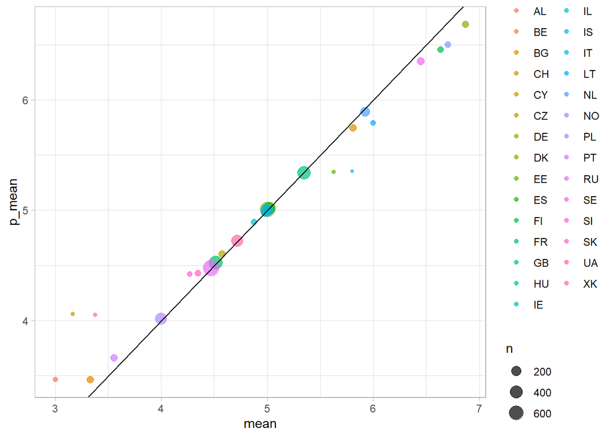

```r
ggplot(aes(x = mean,
           y = p_mean,
           color = cntry),
       data = d1) +
  geom_point(alpha = .7,
             aes(size = n)) +
  geom_abline(intercept = 0,
              slope = 1) ## predicted mean will be close to mean for countries with more data. So a line with slope of 1 is the standard assuming predicted mean equals empirical mean.
```

My predictions were correct for question 3. The countries with more data (i.e., higher n in the plot) had predicted means closer to their empirical means. For those with smaller sample sizes, the means shifted more to be closer to the overall mean.

# Two Dimensions

## 10. Eduyrs Variable

```r
d2 <- d |>
  mutate(eduyrs01 = eduyrs / max(d$eduyrs)) ## eduyrs goes from 0 to 20 so this is appropriate to rescale

m3 <- lmer(ppltrst ~ 1 + eduyrs01 + (1 | cntry),
           data = d2,
           REML = FALSE)
```

By adding the rescaled predictor eduyrs01 to the model, the model suggests that the effect of going from 0 education to the highest level of education in any country is an increase in ppltrst of 1.6402736.

## 11. Trust by Education Plot

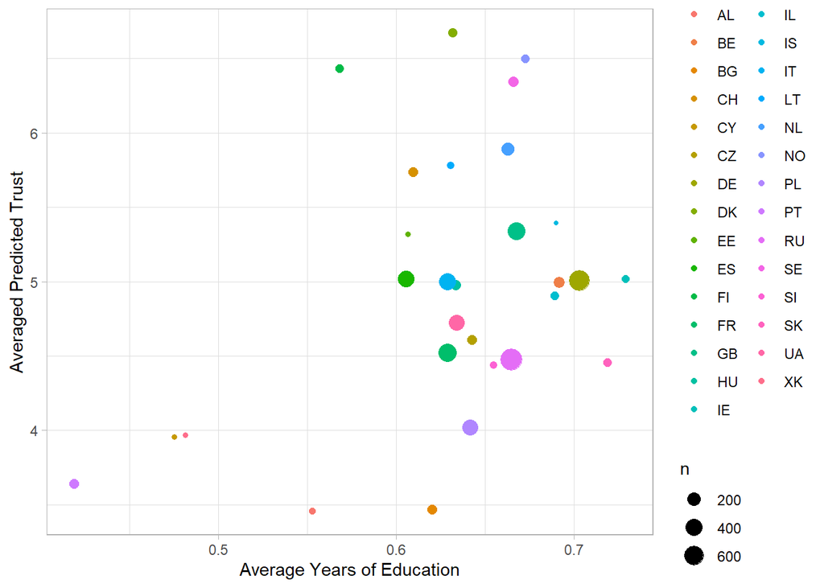

```r
d3 <- d2 |>
  mutate(p_mean = predict(m3, newdata = d2)) |>
  group_by(cntry) |>
  summarize(mean_ppltrst = mean(ppltrst),
            p_mean_ppltrst = mean(p_mean),
            mean_eduyrs = mean(eduyrs01),
            n = n())

ggplot(aes(x = mean_eduyrs,
           y = p_mean_ppltrst,
           color = cntry),
       data = d3) +
  geom_point(aes(size = n)) +
  labs(x = "Average Years of Education",
       y = "Averaged Predicted Trust")
```

## 12. Random Slope Model

[figure not shown]

```r
m4 <- lmer(ppltrst ~ 1 + eduyrs01 + (1 + eduyrs01 | cntry),
           data = d2,
           REML = FALSE)

d4 <- d2 |>
  mutate(p_mean = predict(m3, newdata = d2)) |>
  group_by(cntry) |>
  summarize(mean_ppltrst = mean(ppltrst),
            p_mean_ppltrst = mean(p_mean),
            mean_eduyrs = mean(eduyrs01),
            n = n())

ggplot(aes(x = mean_eduyrs,
           y = p_mean_ppltrst,
           color = cntry),
       data = d4) +
  geom_point(aes(size = n)) +
  labs(x = "Average Years of Education",
       y = "Averaged Predicted Trust")
```

## 13. Comparison of Models

```r
anova(m3, m4)
```

```
Data: d2
Models:
m3: ppltrst ~ 1 + eduyrs01 + (1 | cntry)
m4: ppltrst ~ 1 + eduyrs01 + (1 + eduyrs01 | cntry)
   npar   AIC   BIC logLik -2*log(L)  Chisq Df Pr(>Chisq)
m3    4 22410 22436 -11201     22402
m4    6 22412 22451 -11200     22400 2.0851  2     0.3526
```

There is no meaningful improvement between the models with and without random slopes. As a result, we should pick the less complex model (the first model we tested), which has a lower AIC and BIC.

This suggests that the effect of education on trust is similar for each country, so we do not need to estimate different effects for each country.

# Multivariate Model

## Age on Trust

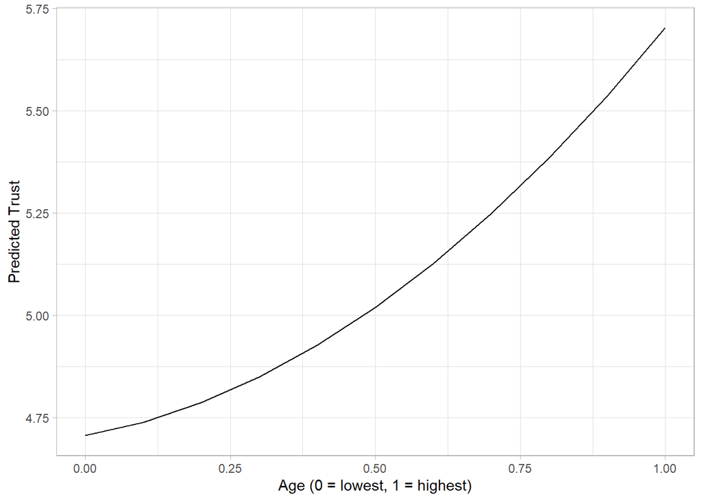

```r
d5 <- d2 |>
  mutate(agea01 = (agea - min(d2$agea)) / (max(d2$agea) - min(d2$agea)),
         attend01 = (attend - min(d2$attend)) / (max(d2$attend) - min(d2$attend)),
         health01 = (health - min(d2$health)) / (max(d2$health) - min(d2$health)))

m5 <- lmer(ppltrst ~ 1 + agea01 + I(agea01^2) + attend01 + health01 + female + eduyrs01 + (1 | cntry),
           data = d5,
           REML = FALSE)

d6 <- ggeffects::ggeffect(m5,
         terms = "agea01")

ggplot(aes(x = x,
           y = predicted),
       data = d6) +
  geom_line() +
  labs(x = "Age (0 = lowest, 1 = highest)",
       y = "Predicted Trust")
```